# Coin Flipping MC Project

Kaushik Kancharla

1/9/2023

# Fake Coin Flip Detection Using Monte Carlo and Statistic Values

We humans tend to believe we can do a decent job in creating a “random” sequence of events. However, given a large enough sample size of predictions, it can be shown that our thinking of randomness is quite flawed. In this project I will show how we can use statistical methods to gain a further understanding of a sequence of events and try to be able to predict whether the sequence of events is truly random. In particular, our sequence of events will be a fair coin flip.

To start, take a look at the following sequence of 200 coin flips:

flips1 = “HTHTHTHTHTHTHTHTHTHTHTHTHTHTHTHTHTHTHTHTHTHTHTHTHTHTHTHTHTHT…”

flips2 = “HHHTHTTTHHTHHTHHHTTTTHTHTHHTTHTHHHTHHTHTTTHTHHHTHTTTHTHTHHTH…”

flips3 = “HHTHTHTTTHTHHHTHHTTTHTHHTHTTTHTHTHHTHTHTTHTHHHHHHTTTHTHTHHTH…”

flips4 = “HTHHHHHHHTHTTHHTTHHHTHTHTTTHHTHHHTHHTTHTTTTTTTTTHTHHTTTTTHTH…”

flips5 = “HHHHHHHHHHTTTTTTTTTTHHHHHHHHHHTTTTTTTTTTHHHHHHHHHHTTTTTTTTTT…”

flips6 = “TTHTTTHTTTTTTTHTHTHTHTTHTTHTHHTHHTTTHHTHTTTHTHHTHHHTHTTHHTHH…”

Try to guess which ones are fake and which ones are real. Some of these are quite obvious but others are not. What if I told you that only one of the above sequence of flips was truly random and the others were human generated? Lets try to find which one of the above flips is random.

## Different Tests

There are many different tests we can do to analyze how random a sequence is. For this project however, we will look at the following tests and combine them with Monte Carlo Simulation to see what the distributions of these tests looks like:

- Longest Run (of either heads or tails)
- The number of changes from a run of heads to tails and vice versa
- The Ratio of Heads to Tails
- The Running Odds Ratio

```r
#Longest Run Function
longestRun = function(flips){
  # the first flip is always a run of length 1.
  MaxRunSoFar = 1
  currentRun = 1

  for(i in 2:length(flips)){ # for every flip
    # if it is equal to the last flip
    if(flips[i]==flips[i-1]){
      # then increase the length of the currentRun
      currentRun = currentRun + 1
      # and if the run is larger than the maxRunSoFar, redefine that.
      if(currentRun>MaxRunSoFar) MaxRunSoFar = currentRun
    }
    # otherwise,
    if(flips[i]!=flips[i-1]){
      # set the current run back to 1
      currentRun=1
  }
  }
  return(MaxRunSoFar)
}

#numbchanges function to see times H changes to T and vice-versa
numbchanges = function(flips){

  Changes = 0

  for(i in 2:length(flips)){
    if(flips[i]!=flips[i-1]){
      Changes=Changes+1
  }
  }
  return(Changes)
}

#HtoT function to see ratio of H to T
HtoT = function(flips){
  counts = table(flips)
  return(counts["H"]/(200-counts["H"]))
}

#Running Odds function
if(!"runner" %in% rownames(installed.packages())) install.packages("runner")
ROf = function(flips){
  tb = table(runner::runner(flips,k=2,f=paste,collapse="")[-1])
  ratioFromTable = setNames((tb["HH"]/tb["HT"])/(tb["TH"]/tb["TT"]),"R")
  return(ratioFromTable)

}


split = function(str) strsplit(str, split="")[[1]]
```

## Monte Carlo Simulations on Tests

To see how the test values are distributed in random runs, we will simulate 1000 random runs of 200 coin flips.

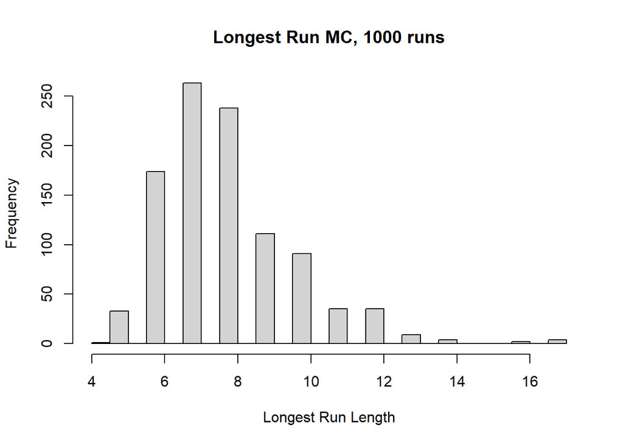

```r
#Longest Run
simulate_S = function(){
  S = sample(c("H","T"), 200,replace=T) %>% longestRun()
  return(S)
}
r = 1000
monte_carlo = data.frame(replicate = 1:r,
                         S = rep(NA,r),
                         S_in_A = rep(NA, r))

for(i in 1:r){
  monte_carlo$S[i] = simulate_S()
}
hist(monte_carlo$S, breaks = 20, main = "Longest Run MC, 1000 runs", xlab = "Longest Run Length")
```

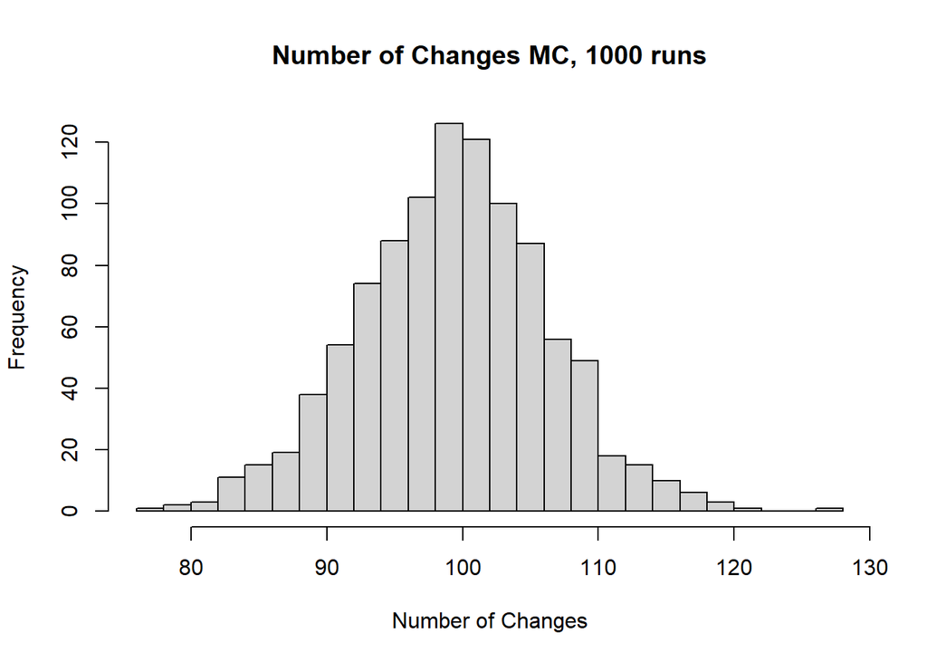

```r
#----------------------------------------
#Number of Changes
simulate_nc = function(){
  S = sample(c("H","T"), 200,replace=T) %>% numbchanges()
  return(S)
}
monte_carlo2 = data.frame(replicate = 1:r,
                         S = rep(NA,r),
                         S_in_A = rep(NA, r))
for(i in 1:r){
  monte_carlo2$S[i] = simulate_nc()
}
hist(monte_carlo2$S, breaks = 20, main = "Number of Changes MC, 1000 runs", xlab = "Number of Changes")
```

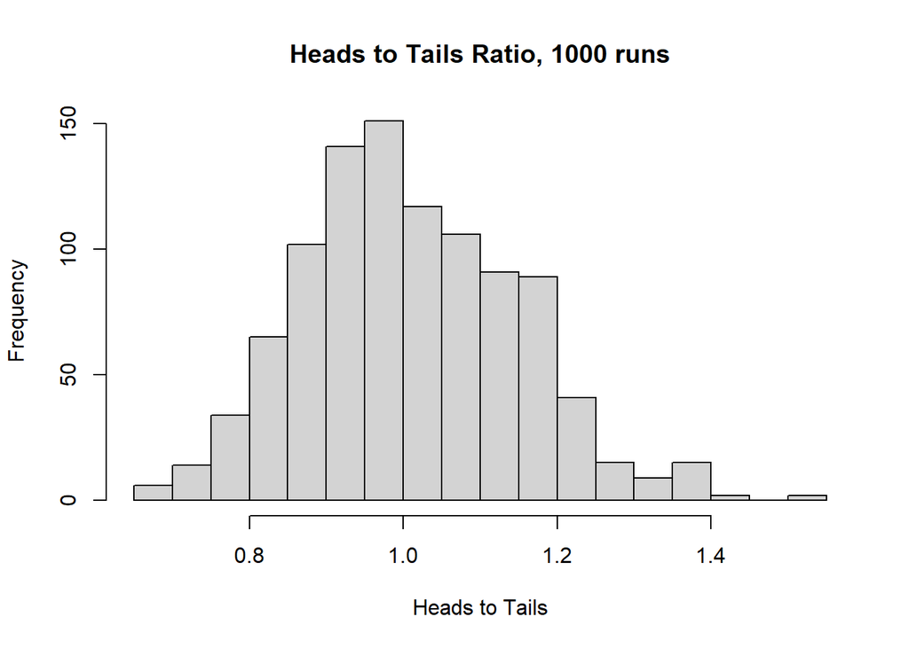

```r
#----------------------------------------
#Heads to Tails ratio
simulate_ht = function(){
  S = sample(c("H","T"), 200,replace=T) %>% HtoT()
  return(S)
}
monte_carlo3 = data.frame(replicate = 1:r,
                         S = rep(NA,r),
                         S_in_A = rep(NA, r))
for(i in 1:r){
  monte_carlo3$S[i] = simulate_ht()
}
hist(monte_carlo3$S, breaks = 20,  main = "Heads to Tails Ratio, 1000 runs", xlab = "Heads to Tails")
```

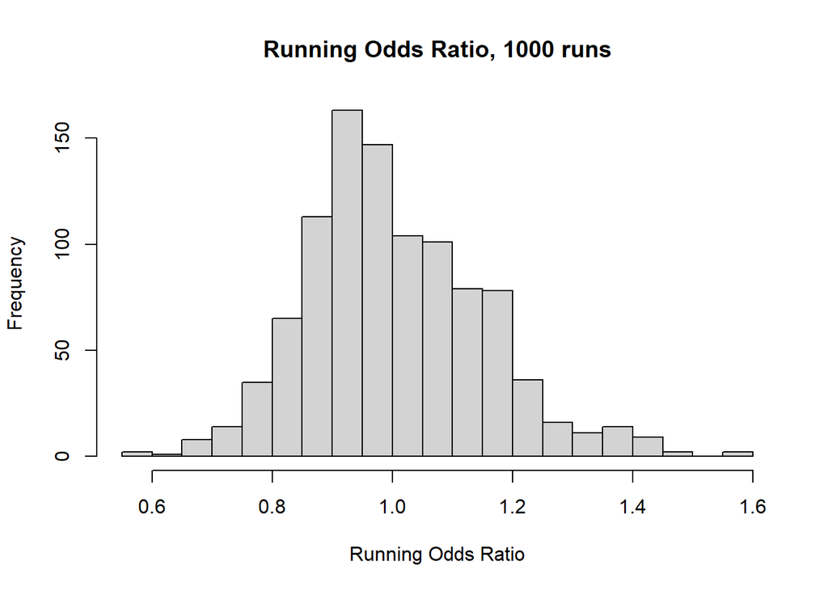

```r
#----------------------------------------
#Running Odds
simulate_RO = function(){
  S = sample(c("H","T"), 200,replace=T) %>% ROf()
  return(S)
}
monte_carlo4 = data.frame(replicate = 1:r,
                         S = rep(NA,r),
                         S_in_A = rep(NA, r))
for(i in 1:r){
  monte_carlo4$S[i] = simulate_ht()
}
hist(monte_carlo4$S, breaks = 20, main = "Running Odds Ratio, 1000 runs", xlab = "Running Odds Ratio")
```

Knowing that the Number of Changes test is symmetric and should follow a normal distribution, we can approximate it as such.

As for the two Ratio tests and the Longest Run test, they follow a skewed distribution so we can approximately make a distribution function for them using the log norm distribution.

```r
#Fit Estimations
library(fitdistrplus)
#Longest Run Log-Norm Distribution
fitLR = fitdist(monte_carlo$S, distr = "lnorm", method = "mle")
summary(fitLR)
```

```
## Fitting of the distribution ' lnorm ' by maximum likelihood
## Parameters :
##          estimate  Std. Error
## meanlog 2.0477894 0.006916688
## sdlog   0.2187249 0.004890377
## Loglikelihood:  -1946.787   AIC:  3897.575   BIC:  3907.39
## Correlation matrix:
##         meanlog sdlog
## meanlog       1     0
## sdlog         0     1
```

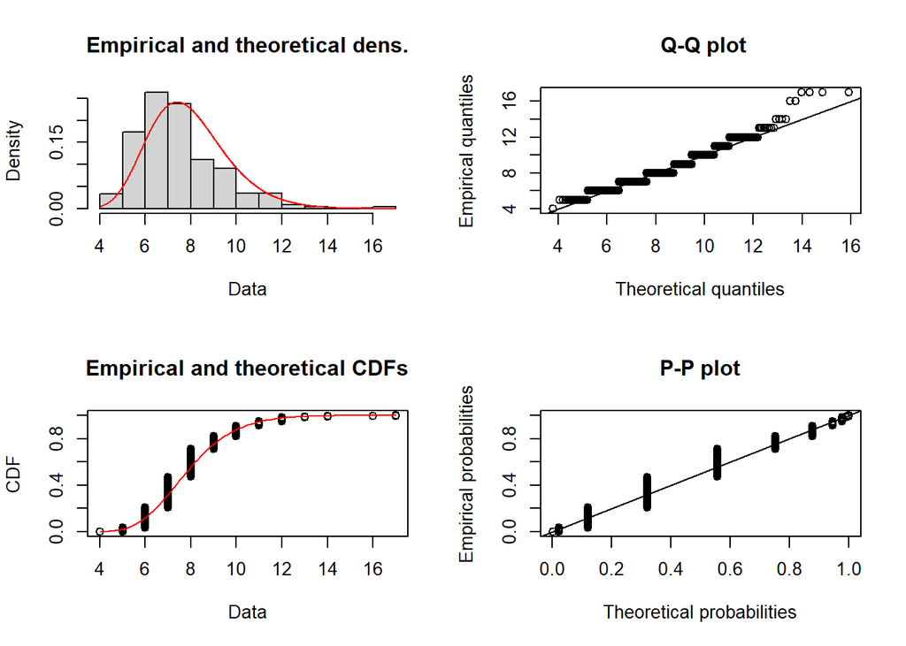

```r
plot(fitLR)
```

```r
#Number of Changes Normal Distribution
fitNC = fitdist(monte_carlo2$S, distr = "norm", method = "mle")
summary(fitNC)
```

```
## Fitting of the distribution ' norm ' by maximum likelihood
## Parameters :
##       estimate Std. Error
## mean 99.849000  0.2204409
## sd    6.970954  0.1558753
## Loglikelihood:  -3360.691   AIC:  6725.381   BIC:  6735.197
## Correlation matrix:
##      mean sd
## mean    1  0
## sd      0  1
```

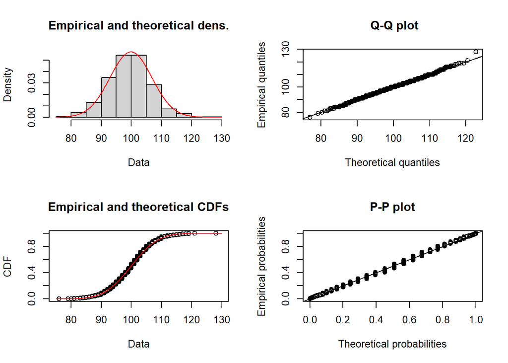

```r
plot(fitNC)
```

```r
#Heads to Tails Log-Norm Distribution
fitHT = fitdist(monte_carlo3$S, distr = "lnorm", method = "mle")
summary(fitHT)
```

```
## Fitting of the distribution ' lnorm ' by maximum likelihood
## Parameters :
##              estimate  Std. Error
## meanlog -0.0009663931 0.004459985
## sdlog    0.1410371087 0.003152972
## Loglikelihood:  540.7601   AIC:  -1077.52   BIC:  -1067.705
## Correlation matrix:
##         meanlog sdlog
## meanlog       1     0
## sdlog         0     1
```

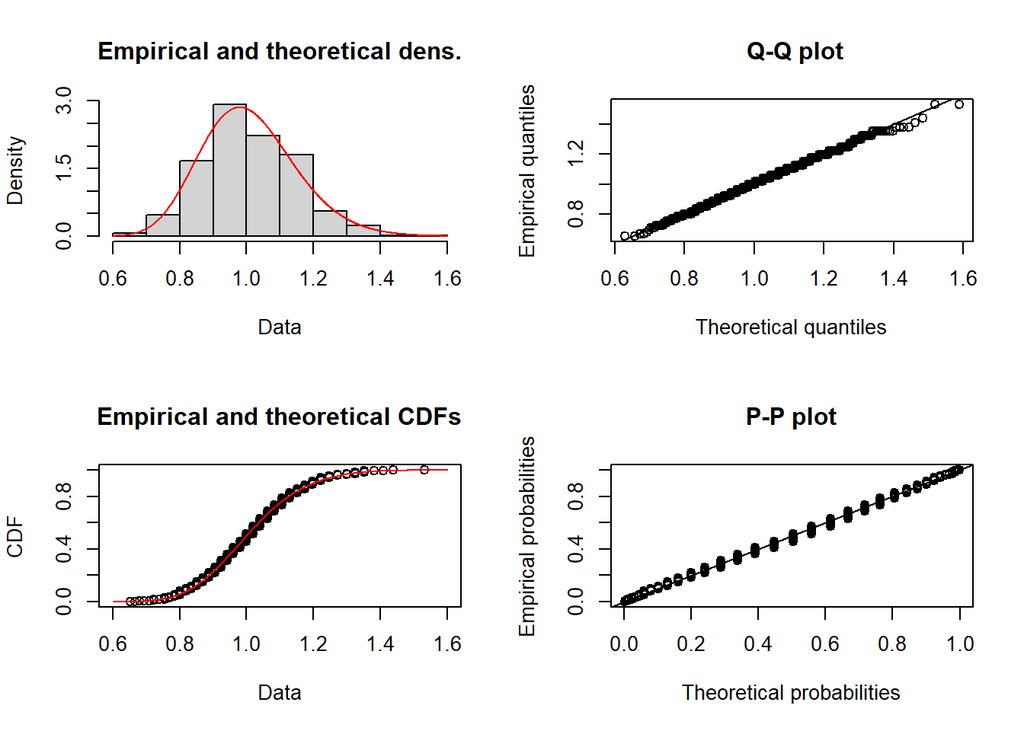

```r
plot(fitHT)
```

```r
#Running Odds Ratio Log-Norm Distribution
fitRoR = fitdist(monte_carlo4$S, distr = "lnorm", method = "mle")
summary(fitRoR)
```

```
## Fitting of the distribution ' lnorm ' by maximum likelihood
## Parameters :
##             estimate  Std. Error
## meanlog -0.007842536 0.004667734
## sdlog    0.147606700 0.003299904
## Loglikelihood:  502.108   AIC:  -1000.216   BIC:  -990.4004
## Correlation matrix:
##               meanlog         sdlog
## meanlog  1.000000e+00 -2.188909e-13
## sdlog   -2.188909e-13  1.000000e+00
```

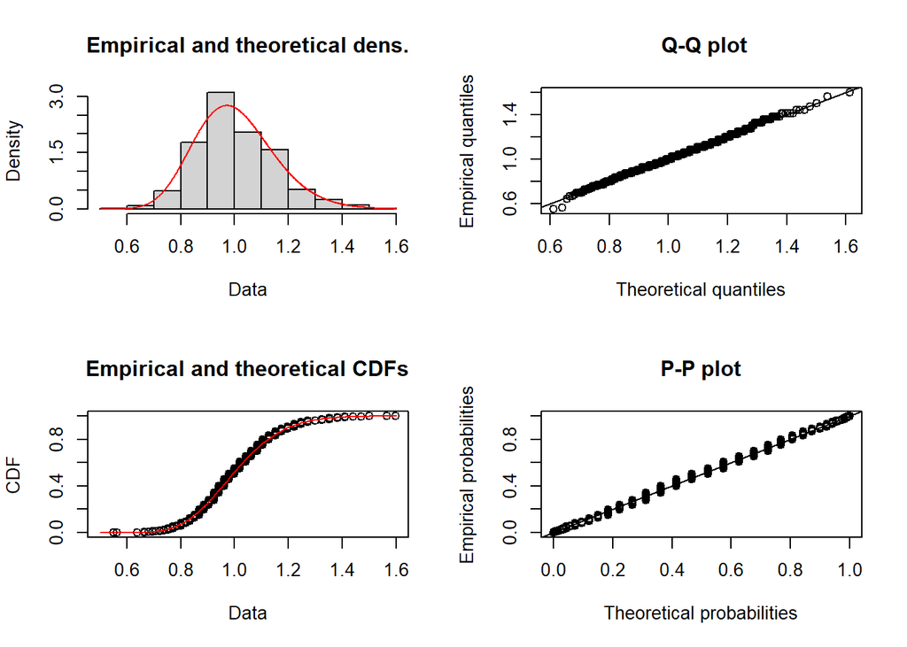

```r
plot(fitRoR)
```

Now that we have the respective probability functions of the above tests, let’s make a function that will give a basic test statistic for how extreme a given value is.

```r
printStatistics = function(flips){
  pval1 = plnorm(longestRun(split(flips)), fitLR$estimate[1], fitLR$estimate[2])
  stat1 = min(pval1, 1-pval1)

  pval2 = pnorm(numbchanges(split(flips)), fitNC$estimate[1], fitNC$estimate[2])
  stat2 = min(pval2, 1-pval2)

  pval3 = plnorm(HtoT(split(flips)), fitHT$estimate[1], fitHT$estimate[2])
  stat3 = min(pval3, 1-pval3)

  pval4 = plnorm(ROf(split(flips)), fitRoR$estimate[1], fitRoR$estimate[2])
  stat4 = min(pval4, 1-pval4)

  return(c(stat1, stat2, stat3, stat4))
}
#Flips
flips1 = "HTHTHTHTHTHTHTHTHTHTHTHTHTHTHTHTHTHTHTHTHTHTHTHTHTHTHTHTHTHT…"

flips2 = "HHHTHTTTHHTHHTHHHTTTTHTHTHHTTHTHHHTHHTHTTTHTHHHTHTTTHTHTHHTH…"

flips3 = "HHTHTHTTTHTHHHTHHTTTHTHHTHTTTHTHTHHTHTHTTHTHHHHHHTTTHTHTHHTH…"

flips4 = "HTHHHHHHHTHTTHHTTHHHTHTHTTTHHTHHHTHHTTHTTTTTTTTTHTHHTTTTTHTH…"

flips5 = "HHHHHHHHHHTTTTTTTTTTHHHHHHHHHHTTTTTTTTTTHHHHHHHHHHTTTTTTTTTT…"

flips6 = "TTHTTTHTTTTTTTHTHTHTHTTHTTHTHHTHHTTTHHTHTTTHTHHTHHHTHTTHHTHH…"
```

Now its time to use this function on our flips data! We can check if any of the statistics are significant by comparing it to significance level of 0.05. If any of the statistics are less than 0.05, we should be cautious in assuming the data is indeed random.

```r
printStatistics(flips1)<0.05
```

```
## [1]  TRUE  TRUE FALSE    NA
```

```r
printStatistics(flips2)<0.05
```

```
## [1]  TRUE  TRUE FALSE  TRUE
```

```r
printStatistics(flips3)<0.05
```

```
## [1] FALSE  TRUE FALSE  TRUE
```

```r
printStatistics(flips4)<0.05
```

```
## [1] FALSE FALSE FALSE FALSE
```

```r
printStatistics(flips5)<0.05
```

```
## [1] FALSE  TRUE FALSE  TRUE
```

```r
printStatistics(flips6)<0.05
```

```
## [1]  TRUE FALSE  TRUE  TRUE
```

Looking at the above output, it is clear to see that only the 4th row has all falses which means that flips4 is the only truly random flip set and the others are most likely non-random (a human faked them).

## Conclusion

Thank you to Prof. Bi Cheng Wu from my Stat 340 class for the initial spark and base functions used in this project. In the future, if we can get a large number of samples of fake 200 flips, we could train a Machine Learning Model to classify whether a series of 200 flips is fake or not but for now, we will have to look at the statistic values and if they are significant.